# Confidence limits on what you predict: worked solutions

PCB 6455 / BSC 4933: Biometry | Lecture 21

Dr. Brian Maitner

## How to use this

The code from Lecture 21, run, with the numbers it produces, and the exercises solved.

The draws are random, so your last decimal place may differ from mine, more so if you ran extra random code in between. Anything beyond that is worth asking about.

## Setting up

```r
library(bbmle)

base <- "https://github.com/bmaitner/biometry_course/raw/refs/heads/main/data/class_examples/"
occ <- read.csv(paste0(base, "bobwhite_occupancy.csv"))
counts <- read.csv(paste0(base, "bobwhite_counts.csv"))

m_occ <- mle2(n_occupied ~ dbinom(size = n_routes, prob = plogis(a + b * elapsed)),
              start = list(a = 2, b = -0.05), data = occ)
coef(m_occ)
```

```
         a          b
 2.0176881 -0.0618983
```

With the course package installed, `bobwhite_occupancy` and `bobwhite_counts` give the same tables.

## The plug-in corners

```r
ci <- confint(m_occ)
corners <- expand.grid(a = ci["a", ], b = ci["b", ])
corners$occ_2019 <- plogis(corners$a + 22 * corners$b)
corners
```

```
         a           b  occ_2019
1 1.769943 -0.08018315 0.5014785
2 2.275374 -0.08018315 0.6251217
3 1.769943 -0.04388737 0.6909194
4 2.275374 -0.04388737 0.7874884
```

```r
cov2cor(vcov(m_occ))
```

```
           a          b
a  1.0000000 -0.8874955
b -0.8874955  1.0000000
```

Two of the corners go against the correlation of $a$ and $b$, so the data rule them out.

## The recipe: occupancy in 2019

```r
set.seed(21)
draws <- MASS::mvrnorm(1000, mu = coef(m_occ), Sigma = vcov(m_occ))
cor(draws)
```

```
           a          b
a  1.0000000 -0.8923368
b -0.8923368  1.0000000
```

```r
occ19 <- plogis(draws[, "a"] + 22 * draws[, "b"])
quantile(occ19, c(0.025, 0.975))
```

```
     2.5%     97.5%
0.6148255 0.7077323
```

## Your turn: how much was lost?

```r
occ97 <- plogis(draws[, "a"])
drop <- occ97 - occ19
quantile(drop, c(0.025, 0.975))
```

```
     2.5%     97.5%
0.1539496 0.2826175
```

Occupancy fell by about 22 percentage points between 1997 and 2019, and the data are consistent with a drop of anywhere from about 15 to 28.

## Two other ways

Rewrite the model so occupancy in 2019 is a parameter:

```r
occ$from2019 <- occ$elapsed - 22
m_2019 <- mle2(n_occupied ~ dbinom(size = n_routes, prob = plogis(a + b * from2019)),
               start = list(a = 1, b = -0.05), data = occ)
plogis(confint(m_2019, parm = "a"))
```

```
    2.5 %    97.5 %
0.6100209 0.7042821
```

The delta method, for the curious:

```r
g <- function(th){ plogis(th[1] + 22 * th[2]) }
est <- g(coef(m_occ))
slopes <- sapply(1:2, function(i){
  th <- coef(m_occ)
  th[i] <- th[i] + 1e-6
  (g(th) - est) / 1e-6
})
se <- sqrt(drop(t(slopes) %*% vcov(m_occ) %*% slopes))
est + c(-1.96, 1.96) * se
```

```
[1] 0.6110942 0.7055948
```

## The band

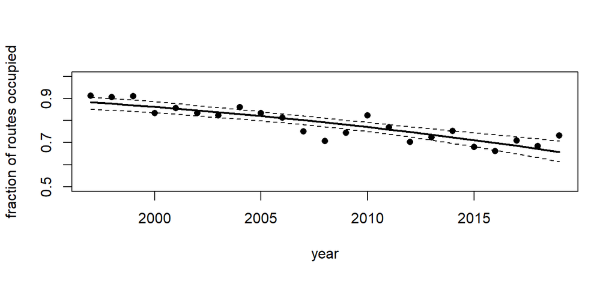

```r
years <- occ$elapsed
curves <- matrix(NA, nrow = 1000, ncol = length(years))
for (i in 1:1000) {
  curves[i, ] <- plogis(draws[i, "a"] + draws[i, "b"] * years)
}
lower <- apply(curves, 2, quantile, 0.025)
upper <- apply(curves, 2, quantile, 0.975)

obs <- occ$n_occupied / occ$n_routes
plot(occ$year, obs, pch = 16, ylim = c(0.5, 1),
     xlab = "year", ylab = "fraction of routes occupied")
lines(occ$year, plogis(coef(m_occ)["a"] + coef(m_occ)["b"] * years), lwd = 2)
lines(occ$year, lower, lty = 2)
lines(occ$year, upper, lty = 2)
```

## The prediction interval

```r
preds <- matrix(NA, nrow = 1000, ncol = length(years))
for (i in 1:1000) {
  p_i <- plogis(draws[i, "a"] + draws[i, "b"] * years)
  preds[i, ] <- rbinom(length(years), size = occ$n_routes, prob = p_i) / occ$n_routes
}
pred_lower <- apply(preds, 2, quantile, 0.025)
pred_upper <- apply(preds, 2, quantile, 0.975)

plot(occ$year, obs, pch = 16, ylim = c(0.5, 1),
     xlab = "year", ylab = "fraction of routes occupied")
lines(occ$year, lower, lty = 2)
lines(occ$year, upper, lty = 2)
lines(occ$year, pred_lower, lty = 3, col = "red")
lines(occ$year, pred_upper, lty = 3, col = "red")
```

```r
c(inside_confidence = sum(obs >= lower & obs <= upper),
  inside_prediction = sum(obs >= pred_lower & obs <= pred_upper))
```

```
inside_confidence inside_prediction
                9                23
```

[figure not shown]

## Counts and development

```r
m_nb <- mle2(count ~ dnbinom(mu = exp(log_mu0 + b * frac_built), size = exp(log_k)),
             start = list(log_mu0 = 2.5, b = -3, log_k = 0), data = counts)
coef(m_nb)
```

```
   log_mu0          b      log_k
 2.4956288 -3.2261733  0.3896322
```

```r
set.seed(22)
draws_nb <- MASS::mvrnorm(1000, mu = coef(m_nb), Sigma = vcov(m_nb))

log(2) / -coef(m_nb)["b"]
```

```
        b
0.2148512
```

```r
log(2) / -confint(m_nb)["b", ]
```

```
    2.5 %    97.5 %
0.1830200 0.2612259
```

```r
quantile(log(2) / -draws_nb[, "b"], c(0.025, 0.975))    # the recipe agrees
```

```
     2.5%     97.5%
0.1831147 0.2608838
```

## Your turn: the band for development

```r
built <- seq(0, 0.5, by = 0.01)
counts_curves <- matrix(NA, nrow = 1000, ncol = length(built))
for (i in 1:1000) {
  counts_curves[i, ] <- exp(draws_nb[i, "log_mu0"] + draws_nb[i, "b"] * built)
}
nb_lower <- apply(counts_curves, 2, quantile, 0.025)
nb_upper <- apply(counts_curves, 2, quantile, 0.975)

plot(counts$frac_built, counts$count, col = "grey", ylim = c(0, 40),
     xlab = "fraction developed", ylab = "bobwhite counted")
lines(built, exp(coef(m_nb)["log_mu0"] + coef(m_nb)["b"] * built), lwd = 2)
lines(built, nb_lower, lty = 2)
lines(built, nb_upper, lty = 2)
```

```r
c(nb_lower[21], nb_upper[21])
```

```
[1] 5.750767 7.028533
```

[figure not shown]

## Your turn: one route

```r
mu_20 <- exp(draws_nb[, "log_mu0"] + draws_nb[, "b"] * 0.2)
quantile(mu_20, c(0.025, 0.975))
```

```
    2.5%    97.5%
5.750767 7.028533
```

```r
one_route <- rnbinom(1000, mu = mu_20, size = exp(draws_nb[, "log_k"]))
quantile(one_route, c(0.025, 0.975))
```

```
 2.5% 97.5%
    0    21
```

We know the average route at 20% developed to within about a bird, but a single route could turn up anywhere from none to around twenty. Both are true: the first is a confidence interval, the second a prediction interval.